# An investigation on the Financial Determinants of Stock Prices : Predictive Machine Learning Modeling with Evidence from the S&P 500

## 6.4 Classification Modelling with the CART algorithm

The results from the “Exploratory Data Analysis (EDA)” section indicate that the variables “Price.Earnings”, “Dividend.Yield”, “Earnings.Share”, “EBITDA”, “PositiveEBITDA”, “Price.Sales”, “Price.Book” and “Dividend” are relevant predictors of the target variable “Price”. As such, for the creation of different modeling algorithms, the following formula is created:

```r
formula_pred = Price ~ Price.Earnings + Dividend.Yield + Earnings.Share + EBITDA + PositiveEBITDA + Price.Sales + Price.Book + Dividend
```

Now, we produce a decision tree based on the CART algorithm. To do this, we use the rpart() function from the rpart package:

```r
tree_CART = rpart(formula = formula_pred, data = train_set, method = "anova")
print(tree_CART)
```

[output not shown]

The CART algorithm produces a decision tree with 5 decision nodes, a root node and 7 leaf nodes. Furthermore, the tree indicates that the CART algorithm selects four predictors (“Earnings.Share”, “Price.Earnings”, “Price.Sales”, “EBITDA”), as the most important predictors for the target variable `Price`. From these four predictors, the variable `Earnings.Share` is selected by the algorithm as the most important predicting variable, as it is the root node of the decision tree. As exemplified by the 7 leaf nodes of the decision tree, 7 predictions are made on the price of an S&P 500 stock. The algorithm predicts that the stock prices will converge to one of the seven categories.

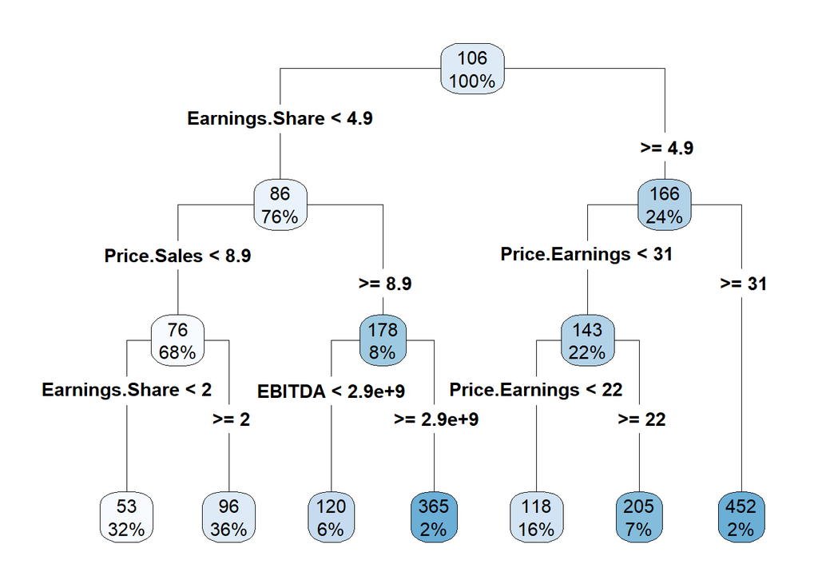

```r
rpart.plot(tree_CART, type = 4, extra = 100)
```

## 6.5 Random Forest

```r
formula_rf = Price ~ Price.Earnings + Dividend.Yield + Earnings.Share + EBITDA + PositiveEBITDA + Price.Sales + Price.Book + Dividend
random_forest = randomForest( formula = formula_rf, data = train_set, importance=TRUE, proximity=TRUE )
```

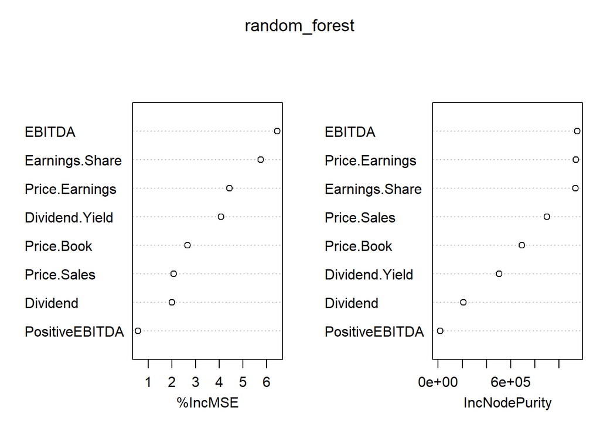

```r
varImpPlot(random_forest)
```

```r
importance(random_forest)
```

[output not shown]

The Mean Decrease Accuracy (%IncMSE) shows how much our model accuracy decreases if we leave out a specific variable. Thus, the highest error value corresponding to the EBITDA variable makes it in our random forest algorithm the most important predictor, followed by the Earnings.Share, Price.Earnings, Dividend.Yield, Price.Book, Price.Sales, Dividend and the PositiveEBITDA.

At the same time, the values in the table denoting the Mean Decrease Gini (IncNodePurity) is a measure of variable importance based on the Gini impurity index used for the calculating the splits in trees. Even though the Mean Decrease Accuracy is good enough for our analysis, if the purity of nod splits is of any interest, then from the most to the least important the variables are ranked in the following way: EBITDA, Price.Earnings, Earnings.Share, Price.Sales, Price.Book, Dividend.Yield, Dividend and PositiveEBITDA.

# 7 Model Evaluation

To evaluate the predictive models, which includes only continuous data, the mean-squared error and the R-squared value are used. In this sense, the combination of the lowest mean squared error and the highest R-squared value are sought. As the target variable is continuous and since the research is not assessing the performance of a binary classifier system, ROC and AUC interpretations are not possible.

## 7.1 Evaluation of the Stepwise Regression Model

```r
predict_step_reg = predict(reg_final, test_set)
(mse(predict_step_reg, actual_test))
```

```
  [1] 12701.01
```

The stepwise regression model has an MSE of 12701.01. Furthermore, the model has an R-squared of 0.1628. This means that the stepwise regression model manages to explain 16.28% of the variance in the stock prices.

## 7.2 Evaluation of the CART algorithm

For the evaluation of the algorithm, a prediction variable is first created as follows and the MSE is calculated:

```r
predict_CART = predict(tree_CART, test_set)

mse_CART = mse(predict_CART, actual_test)
mse_CART
```

```
  [1] 16749.82
```

The R-square reported in the below output:

```r
rsq_cart = (cor(predict_CART, actual_test))**2
rsq_cart
```

```
  [1] 0.05950605
```

The mean-squared error value of 16749.82 shows that the predicted price of a stock faces an error rate of 16749.82. As such, the prediction model provides very inaccurate price predictions. Furthermore, the R-squared value of 0.05950605 proves that only a very little amount, 5.95% to be specific, of the variance of the target variable “Price” is explained by the model.

## 7.3 Evaluation of the Random Forest algorithm

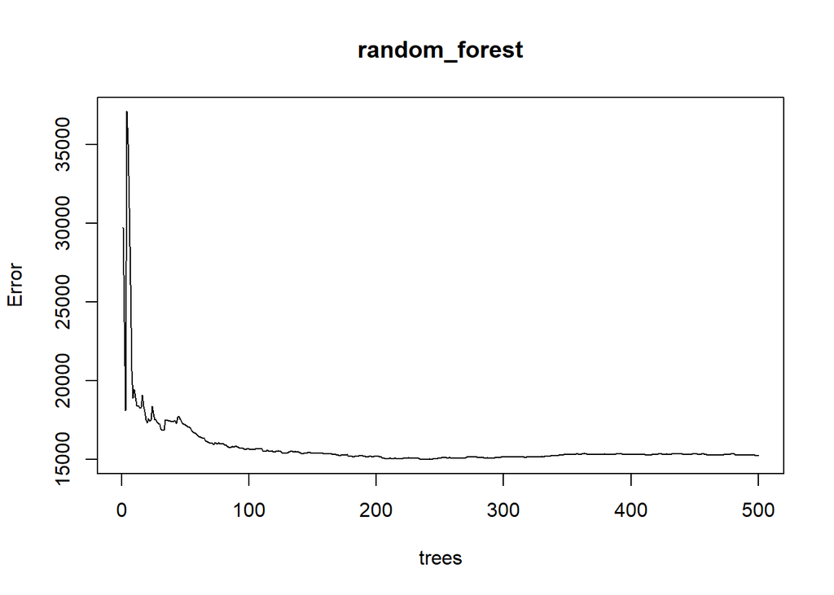

```r
plot(random_forest)
```

```r
print(random_forest)
```

```
  Call:
   randomForest(formula = formula_rf, data = train_set, importance = TRUE,      proximity = TRUE)
                 Type of random forest: regression
                       Number of trees: 500
  No. of variables tried at each split: 2

            Mean of squared residuals: 15755.64
                      % Var explained: 13.3
```

The random forest algorithm has an MSE of 15755.64. Furthermore, 13.3% of the variance in the stock price is explained by the random forest algorithm. It can also be observed that more than 100 trees is sufficient enough to minimize the error rate.

Considering the evaluation of all three models, the random forest algorithm manages to explain more variance in the stock prices compared the CART algorithm with having a lower error compared to the CART algorithm. On top of that, both algorithms have a higher MSE relative to the stepwise regression model in which the regression model also has a higher R-square value. In this sense, it can be concluded that the stepwise regression model performs better than the random forest and CART algorithms. Finally, the CART algorithm predicts poorly as it only classifies stock prices rather than point estimating it.

Therefore, the final model to predict the stock prices of the companies in the S&P 500 is Price = 76.08 + 0.5001 * Price.Earnings - 14.25 * Dividend.Yield + 11.16 * Earnings.Share + 2.695 * 10$^-9$ * EBITDA + 5.321 * Price.Sales - 29.43 * Dividend

## 7.4 Hypothesis Evaluation and Discussion

Considering the regression model, it can be concluded that companies with higher earnings per share, higher EBITDA and higher price to sales ratio are expected to have a higher stock price. In contrast, paying dividends and the dividend yield itself lower the price prediction for the stocks.

The most significant financial determinant of the stock prices is the dividend yield, earnings per share, EBITDA, price-sales ratio and whether the company is paying dividends, In this regard, for every one unit increase in price-earnings ratio the stock price goes up by $0.5001, for every one unit increase in dividend yield the stock price goes down by $14.25, for every one unit increase in the earnings per share the stock price goes up by $11.16, for every one unit increase in EBITDA the stock price goes up by $2.695 * 10$^-9$, for every one unit increase in the price-sales ratio the stock price goes up by $5.321, and finally if the company is paying dividends, the stock price goes down by $29.43.

Taking into account that the model explains 16.28% of the variance for the prices, it correctly predicts the stock prices only 16.28% of the times that is not in line with the initial hypothesis of the research. Therefore we do not have statistically significant evidence to state that stock prices can be predicted accurately at 50% of the times simply using the financial information of companies and therefore we do not accept **H1** (proportion of correctly predicted stocks is at least 50%). Based on this, sub-hypotheses give insights about the model and further research. In this sense, **H2c** is accepted (companies that have a higher earnings per share ratio have a higher price prediction), **H2d** is accepted (the sector of the companies have no effect on the stock price) as presented in the EDA, **H2e** is accepted (companies with higher price-sales ratio have a higher price prediction). On the other hand, **H2a** is not accepted (companies that pay dividends have a higher price prediction), **H2b** is not accepted (companies that have a higher dividend yield have a higher price prediction), **H2f** is not accepted (companies with lower price-book ratio have a higher price prediction) as price-book ratio is insignificant for price prediction at $\alpha=0.05$.

# 8 Conclusion

With the challenges of the financial information on the determinants of stock prices, the impacts of financial information on the movements of the stock price were challenged where the prolonged criticism on the Efficient Market Hypothesis stated that not all available information is reflected on the prices. In light of the previous literature on the issue, as it is believed that data modeling can conclude a solution, the research investigated the financial determinants of stock prices by taking into account the research question of ‘To what extent does the financial information of companies have an effects on stock prices?’. The analysis initially observed how all variables in the dataset interacted with the target variable `Price`. Following, based on the statistical significance of variables and the previous literature, the research classifies the financial information that are important for determining the stock price on several variables namely, `Price.Earnings`, `Dividend.Yield`,`Earnings.Share`, `EBITDA`, `PositiveEBITDA`, `Price.Sales`, `Price.Book`, `Dividend`. By utilizing the given variables, the research undertakes three modeling stages: multiple regression model, CART algorithm and the random forest algorithm.

Considering the objective and the methodology of the research, the results of the data analysis suggest that financial information of companies are not statistically sufficient in determining the stock prices by providing evidence from the companies in the S&P 500 index. In this sense, **H1** of the research is not accepted. Even though the null hypothesis does not have sufficient support, there is robust evidence that certain financial information contribute in determining the stock price. In this sense, the sub-hypotheses **H2c**, **H2d** and **H2e** are accepted. In other words, the research concludes that financial information is not enough by itself in predicting stock prices although information on the price-earnings ratio, dividend yield, earnings per share, EBITDA, price-sales ratio and paying dividend has a significant affect as a determinant for stock price. Therefore, as mentioned in the theoretical background, the research contributes to the existing literature by providing data-driven evidence that the Efficient Market Hypothesis no longer holds and financial information is not enough in determining stock prices.

All in all, the research contributes to the literature by laying the importance of data science in the financial sector where conventional theory may fail due to the paradigm shifts in the area through financial crises. The aforementioned findings of the research can be attributed to two main reasons that can be labeled as the limitations of the research. Firstly, with the developments in **globalization** and interconnectedness of economies in the recent century, created an environment where financial markets are more vulnerable to global macroeconomic condition as well as foreign economic policies. The rapid access to information undermines the importance of financial information as changes in prices can be explained by various elements such as regional politics and economic development. Additionally, with the improvements in globalization, changes in a stock market may impact the others which makes the system inter-dependent. Therefore, market valuation of a company may also reflect the developments in other markets as investors also take into account the financial information of competitors or subcontractor which makes financial information less significant as a determinant of the stock price. Secondly, with the effects of globalization, **the time that the financial information is reflected** on the prices is also a matter of discussion with the developments of technology. As the amount of news about a company grows with the access to technology, it also gets faster for the market to internalize the information and reflect the news on the prices. In other words, the absorption of financial information is faster which also makes its importance fade rapidly. Therefore, the small time frame that the financial information is reflected on the prices may make financial information less important as other determinants also take part in the meantime.

The given reasons present recommendations for investors and financial professionals as shown in the introduction section to prevent future financial crises and give logical investment decisions. It is important to take into account that investors should not merely look into the balance sheet of companies and decide on an investment strategy. Data driven investment strategies should also take into account macroeconomic variables and market sentiment when creating a predictive machine learning model. Furthermore, the research gives insights for policy makers where regulation on capital markets should also aim at the transparency of non-financial information to prevent future financial crises which is shown to play a key role for the savings and the prosperity of the society. In this sense, institutions should take strict measures for disinformation and manipulation that utilize non-financial information to distort the market predictions.

Finally, the research lays the foundation for future research recommendations where the limitations and the assumptions are adjusted. Further research can take into account various macroeconomic variables to observe how much financial information play a role in predicting stock prices relative to the macroeconomic condition. Another aspect to be challenged can be to observe a cross-sectional time series analysis where the importance of financial information on determining stock prices can be analyzed before and after a financial crisis.

# 9 References

Arner, D. W. (2009). The Global Credit Crisis of 2008: Causes and Consequences. The International Lawyer, 43(1), 92–112. https://doi.org/10.2139/ssrn.1330744

Bekiros, S., Gupta, R., & Kyei, C. (2016). On economic uncertainty, stock market predictability and nonlinear spillover effects. The North American Journal of Economics and Finance, 36, 184–191. https://doi.org/10.1016/j.najef.2016.01.003

Berk, J. D., & DeMarzo, P. (2019). Corporate finance (5th ed.). Pearson.

Bernanke, B. S. (2018). The real effects of disrupted credit: Evidence from the global financial crisis. Brookings Papers on Economic Activity, 2018(2), 254. https://doi.org/10.1353/eca.2018.0012

Bernard, V. L. (1994). Accounting-Based Valuation Methods, Determinants Of Market-To-Book Ratios, And Implications For Financial Statement Analysis. University of Michigan. https://deepblue.lib.umich.edu/handle/2027.42/35398

Branch, B. S., Sharma, A., Chawla, C., & Tu, F. (2015). An Updated Model of Price-to-Book. Journal of Applied Finance, 24(1). https://ssrn.com/abstract=2682606

Choudhry, M. T., Marelli, E., & Signorelli, M. (2012). Youth unemployment rate and impact of financial crises. International journal of manpower, 33(1), 76-95. https://doi.org/10.1108/01437721211212538

Danielson, M. G., & Lipton, A. (2015). Are Some Stock Prices Destined to Fall? SSRN, 22(1). https://ssrn.com/abstract=2690264

Denis, D. J., & Sibilkov, V. (2010). Financial Constraints, Investment, and The Value of Cash Holdings. SSRN Electronic Journal. https://doi.org/10.2139/ssrn.1030065

de Wet, J. (2013). Earnings per Share as a Measure of Financial Performance: Does it Obscure More Than it Reveals? Corporate Ownership and Control, 10(4), 265-275. https://doi.org/10.22495/cocv10i4c2art3

Esparcia, C., & López, R. (2022). Outperformance of the pharmaceutical sector during the COVID-19 pandemic: Global time-varying screening rule development. Information Sciences, 609, 1181-1203. https://doi.org/10.1016/j.ins.2022.07.146

Fama, E. F. (1970). Efficient capital markets: A review of theory and empirical work. The Journal of Finance, 25(2), 383. https://doi.org/10.2307/2325486

Feldstein, M., & Green, J. (1983). Why do companies pay dividends? The American Economic Review. https://doi.org/10.3386/w0413

Friend, I., & Puckett, M. (1964). Dividends and Stock Prices. The American Economic Review, 54(5), 656-682. https://www.jstor.org/stable/1818565

Hermann, C. (2017). Another ‘lost decade’? Crisis and structural adjustment in Europe and Latin America. Globalizations, 14(4), 529-530. https://doi.org/10.1080/14747731.2016.1236464

ILO. (2014). Global employment trends 2014: Risk of a jobless recovery?. International Labour Organization, 17. https://www.ilo.org/wcmsp5/groups/public/---dgreports/---dcomm/---publ/documents/publication/wcms_233953.pdf

Ismail, M. R., Khan, T. R., Choudhury, T. T., & Adnan, A. M. (2014). How Earning per Share (Eps) Affects on Share Price. European Journal of Business and Management, 5(2), 11-18. https://core.ac.uk/download/pdf/234625577.pdf

Karanikolos, M., Heino, P., McKee, M., Stuckler, D., & Legido-Quigley, H. (2016). Effects of the global financial crisis on health in high-income OECD countries: a narrative review. International journal of health services, 46(2), 216. https://doi.org/10.1177/0020731416637160

Karanikolos, M., Mladovsky, P., Cylus, J., Thomson, S., Basu, S., Stuckler, D., … & McKee, M. (2013). Financial crisis, austerity, and health in Europe. The Lancet, 381(9874), 1323-1331. https://doi.org/10.1016/s0140-6736(13)60102-6

Lander, J., Orphanides, A., & Douvogiannis, M. (1997). Earnings Forecasts and the Predictability of Stock Returns : Evidence from Trading the S&P. Finance and Economics Discussion Series, 1997(06), 1-25. https://doi.org/10.17016/feds.1997.06

Malkiel, B. G. (2003). The Efficient Market Hypothesis and Its Critics. Journal of Economic Perspectives, 17(1). https://eml.berkeley.edu/~craine/EconH195/Fall_16/webpage/Malkiel_Efficient%20Mkts.pdf

Mulligan, T. (1986). A Critique of Milton Friedman’s Essay ’The Social Responsibility of Business is to Increase Its Profits? Journal of Business Ethics, 5(4), 265-269. https://doi.org/10.1007/bf00383091

Ollivaud, P., & Turner, D. (2014). The effect of the global financial crisis on OECD potential output. OECD Economics Department Working Papers, 1166, 48. https://doi.org/10.1787/5jxwtl8h75bw-en.

Siegel, J. J. & Schwartz, J. D. (2006). Long-Term Returns on the Original S&P 500 Companies. Financial Analysts Journal, 62(1), 18–31. https://doi.org/10.2469/faj.v62.n1.4055

Vruwink, D. R., Quirin, J. J., & O’Bryan, D. (2007). A modified price-sales ratio: A useful tool for investors? Journal of Business & Economics Research (JBER), 5(12). https://doi.org/10.19030/jber.v5i12.2613

Wang, Y. (2014). Stock price direction prediction by directly using prices data: An empirical study on the KOSPI and HSI. International Journal of Business Intelligence and Data Mining, 9(2), 145. https://doi.org/10.1504/IJBIDM.2014.065091

Ying, Q., Yousaf, T., Ain, Q. U., Akhtar, Y., & Rasheed, M. S. (2019). Stock investment and excess returns: A critical review in the light of the efficient market hypothesis. Journal of Risk and Financial Management, 12(2), 97. https://doi.org/10.3390/jrfm12020097